# Data Science Insight: Ensembling and Stacked Generalization

### October 30, 2020

The `keras` library allows multiple `Functional` deep learning models to be nested. What can result is model ensembling, a method to imrpove prediction accuracy by averaging the predictions from multiple models.

Those last two sentences contained a lot of deep learning jargon so let’s break it down. Neural networks are one type of machine learning model that can be use to classify data. A subset of neural networks are convolutional neural networks (CNNs) which are great for image data. CNNs take in an input image, identify relevant features of the image and assign importance using weights, and then classify images (typically) into different groups.

The most simple application of CNNs is classify a set of images into dogs and cats. The dataset of images is split into a training set and a test set. The CNN determines the best weights to classify the images as dogs or cats through an iterative process and then the newly trained model can be used to predict whether each test image depicts a dog or a cat.

The problem is, like with any model, CNNs and neural networks are not perfect right out of the box. We as programmers must find ways to improve accuracy. In my [first data science insight](https://github.com/ceh-2000/ABM/blob/master/insight1.md), I talked about transfer learning as one possible model improvement method. Another option is model ensembling. At a high level, this means nesting submodels in a larger model and averaging the predictions of each submodel.

The most basic type of CNN is a Sequential model. One creates it by stacking layers on top of each other to make a model and looks like this.

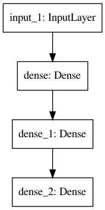

The other kind of model that we want to look at is a Functional model. Functional models can be non-linear, share layers, and have multiple input and outputs. Here is an image depicting one possible structure of a Functional model.

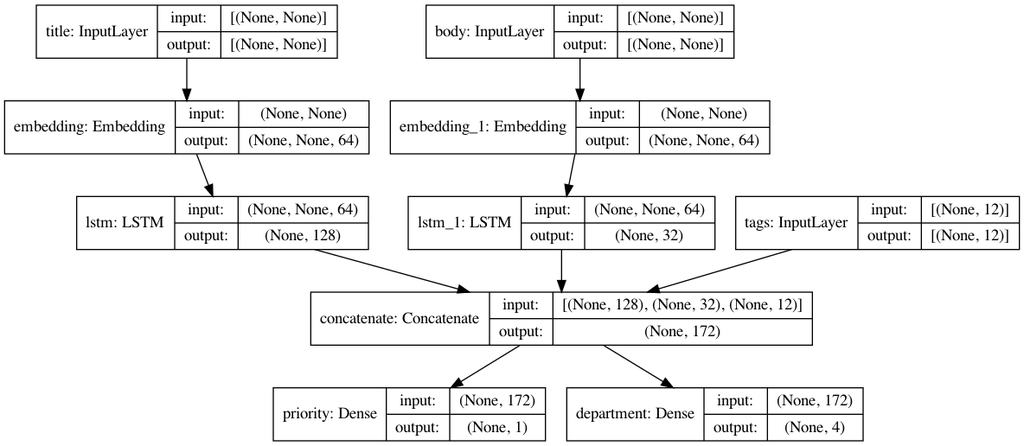

In order to put together multiple models for model ensembling, we want to use Functional models. In this example from the Keras documentation we create three models and then average the predictions of each model.

```r
def get_model():
    inputs = keras.Input(shape=(128,))
    outputs = layers.Dense(1)(inputs)
    return keras.Model(inputs, outputs)

model1 = get_model()
model2 = get_model()
model3 = get_model()

inputs = keras.Input(shape=(128,))
y1 = model1(inputs)
y2 = model2(inputs)
y3 = model3(inputs)
outputs = layers.average([y1, y2, y3])
ensemble_model = keras.Model(inputs=inputs, outputs=outputs)
```

Here, each model’s prediction power is weighted equally since we average each output. This is fine, but what if one model does a much better job of classifying images than the other two (or some other data science task). Shouldn’t this model’s predictions count for more?

Well, we could apply a linear regression technique and weight predictions from the better-performing models more.

But we can do better. We could create another model to dynamically determine how best to weight the predictions of each submodel and what results is some fun model inception. This is called stacked generalization. This method can make better predictions than any single model on its own.

We can break this down into two steps. Let’s go back to our cat and dog example.

Step 1: We define three models to try and predict cats and dogs. We give each model our training image inputs and the weights of each model are adjusted. We make predictions on the data for each model.

Step 2: These predictions for the data from each of our three models are used as inputs for our new model that learns to make even better predictions.

Stacked generalization can even be used to improve the results from one model. For instance, if we only train one model in step one on training data, we can take our predictions and improve them with a second model in step two with validation data. But typically it’s best to use multiple models derived from different algorithms to avoid overfitting.

The “meta-model” that takes in predictions from each of the submodels and aims to provide even better predictions can be anything from a logistic regression model to a neural network. It gets predictions as probabilities for each each class for all training images as inputs and then creates a best fit model that can make better predictions on new test data.

Here is a complete example from [this tutorial](https://machinelearningmastery.com/stacking-ensemble-for-deep-learning-neural-networks/) and the corresponding output:

```r
# Step 1: Build our 5 models
# example of saving sub-models for later use in a stacking ensemble
from sklearn.datasets import make_blobs
from keras.utils import to_categorical
from keras.models import Sequential
from keras.layers import Dense
from matplotlib import pyplot
from os import makedirs

# fit model on dataset
def fit_model(trainX, trainy):
    # define model
    model = Sequential()
    model.add(Dense(25, input_dim=2, activation='relu'))
    model.add(Dense(3, activation='softmax'))
    model.compile(loss='categorical_crossentropy', optimizer='adam', metrics=['accuracy'])
    # fit model
    model.fit(trainX, trainy, epochs=500, verbose=0)
    return model

# generate 2d classification dataset
X, y = make_blobs(n_samples=1100, centers=3, n_features=2, cluster_std=2, random_state=2)
# one hot encode output variable
y = to_categorical(y)
# split into train and test
n_train = 100
trainX, testX = X[:n_train, :], X[n_train:, :]
trainy, testy = y[:n_train], y[n_train:]
print(trainX.shape, testX.shape)
# create directory for models
makedirs('models')
# fit and save models
n_members = 5
for i in range(n_members):
    # fit model
    model = fit_model(trainX, trainy)
    # save model
    filename = 'models/model_' + str(i + 1) + '.h5'
    model.save(filename)
    print('>Saved %s' % filename)


#################################################################
# Step 2: Stacked generalization

# stacked generalization with linear meta model on blobs dataset
from sklearn.datasets import make_blobs
from sklearn.metrics import accuracy_score
from sklearn.linear_model import LogisticRegression
from keras.models import load_model
from keras.utils import to_categorical
from numpy import dstack

# load models from file
def load_all_models(n_models):
    all_models = list()
    for i in range(n_models):
        # define filename for this ensemble
        filename = 'models/model_' + str(i + 1) + '.h5'
        # load model from file
        model = load_model(filename)
        # add to list of members
        all_models.append(model)
        print('>loaded %s' % filename)
    return all_models

# create stacked model input dataset as outputs from the ensemble
def stacked_dataset(members, inputX):
    stackX = None
    for model in members:
        # make prediction
        yhat = model.predict(inputX, verbose=0)
        # stack predictions into [rows, members, probabilities]
        if stackX is None:
            stackX = yhat
        else:
            stackX = dstack((stackX, yhat))
    # flatten predictions to [rows, members x probabilities]
    stackX = stackX.reshape((stackX.shape[0], stackX.shape[1]*stackX.shape[2]))
    return stackX

# fit a model based on the outputs from the ensemble members
def fit_stacked_model(members, inputX, inputy):
    # create dataset using ensemble
    stackedX = stacked_dataset(members, inputX)
    # fit standalone model
    model = LogisticRegression()
    model.fit(stackedX, inputy)
    return model

# make a prediction with the stacked model
def stacked_prediction(members, model, inputX):
    # create dataset using ensemble
    stackedX = stacked_dataset(members, inputX)
    # make a prediction
    yhat = model.predict(stackedX)
    return yhat

# generate 2d classification dataset
X, y = make_blobs(n_samples=1100, centers=3, n_features=2, cluster_std=2, random_state=2)
# split into train and test
n_train = 100
trainX, testX = X[:n_train, :], X[n_train:, :]
trainy, testy = y[:n_train], y[n_train:]
print(trainX.shape, testX.shape)
# load all models
n_members = 5
members = load_all_models(n_members)
print('Loaded %d models' % len(members))
# evaluate standalone models on test dataset
for model in members:
    testy_enc = to_categorical(testy)
    _, acc = model.evaluate(testX, testy_enc, verbose=0)
    print('Model Accuracy: %.3f' % acc)
# fit stacked model using the ensemble
model = fit_stacked_model(members, testX, testy)
# evaluate model on test set
yhat = stacked_prediction(members, model, testX)
acc = accuracy_score(testy, yhat)
print('Stacked Test Accuracy: %.3f' % acc)
```

The relevant output of the following is:

```
Model Accuracy: 0.811
Model Accuracy: 0.800
Model Accuracy: 0.816
Model Accuracy: 0.803
Model Accuracy: 0.814

Stacked Test Accuracy: 0.831
```

As you can see here, the stacked model did better than any individual model. This is the power of stacked generalization in deep learning.

Sources:  
https://keras.io/guides/functional_api/  
https://blog.keras.io/building-powerful-image-classification-models-using-very-little-data.html  
https://machinelearningmastery.com/stacking-ensemble-for-deep-learning-neural-networks/  
https://towardsdatascience.com/a-comprehensive-guide-to-convolutional-neural-networks-the-eli5-way-3bd2b1164a53